# R as a GIS - Basics

Paul Chapron & Hadrien Commenges

April 2019

## Outline

- Loading a variety of types and formats of spatialized data
- Performing basic GIS operations
- Visualizing the results with plots and maps

## Data description

The dataset covers the Paris region.

- Fine-grain administrative boundaries (polygons, ESRI shp)
- Elevation data (raster, ASC)
- Population grid with income data (polygons, Rds)
- GPS tracks for my city walk (points, geoJSON)

## Packages and data

```r
library(sf)
library(raster)
library(leaflet)
library(tidyverse)
```

Load the Paris neighborhoods (Iris perimeters) and **dissolve to get one unified polygon**.

```r
parisNei <- st_read("DATA/Demo/parisnei.shp", crs = 2154, stringsAsFactors = FALSE)
```

[figure not shown]

```r
plot(parisNei$geometry)
```

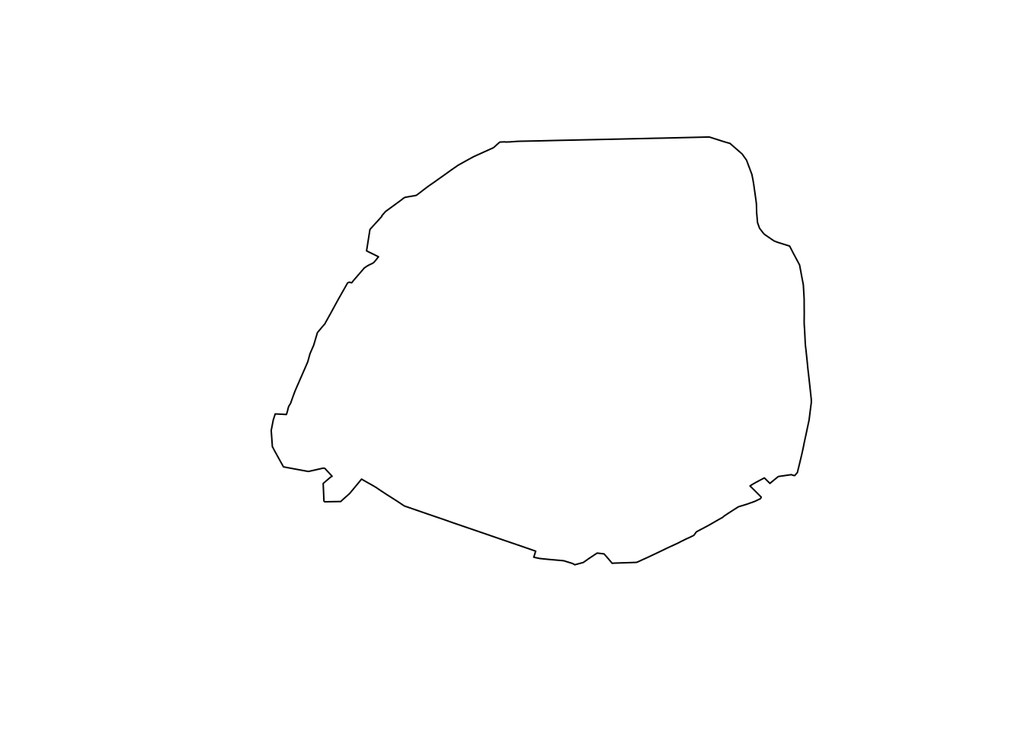

```r
# option 1 (geometry union)
parisUnion <- parisNei %>% st_union()
plot(parisUnion)
```

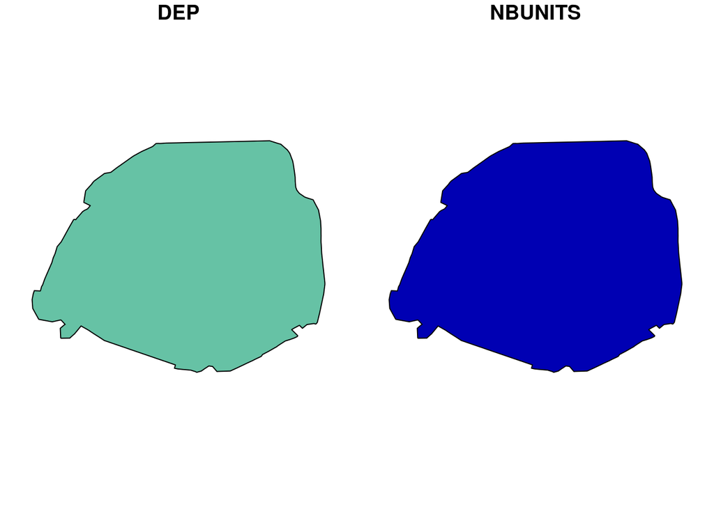

```r
# option 2 (summarizing attributes and dissolving geometries)
parisBound <- parisNei %>%
  group_by(DEP) %>%
  summarise(NBUNITS = n())
plot(parisBound)
```

Load the raster of elevation and **declare the coordinate reference system** (CRS).

```r
rastElev <- raster(x = "DATA/Demo/BDALTI_75.asc")
projection(rastElev) <- CRS("+init=epsg:2154")
```

Load the population grid and **convert to simple feature** format (`sf`).

```r
incomeGrid <- readRDS("DATA/Demo/carroyage.Rds") %>%
  st_as_sf() %>%
  st_set_crs(value = 2154)
st_crs(incomeGrid)
```

```
## Coordinate Reference System:
##   EPSG: 2154
##   proj4string: "+proj=lcc +lat_1=49 +lat_2=44 +lat_0=46.5 +lon_0=3 +x_0=700000 +y_0=6600000 +ellps=GRS80 +towgs84=0,0,0,0,0,0,0 +units=m +no_defs"
```

Load the GPS data from my city walk and **transform the coordinates reference system**.

```r
myRoute <-   st_read("DATA/Demo/myroute.geojson")
st_crs(myRoute)
```

```
## Coordinate Reference System:
##   EPSG: 4326
##   proj4string: "+proj=longlat +datum=WGS84 +no_defs"
```

```r
myRouteProj <- st_transform(myRoute, crs = 2154)
```

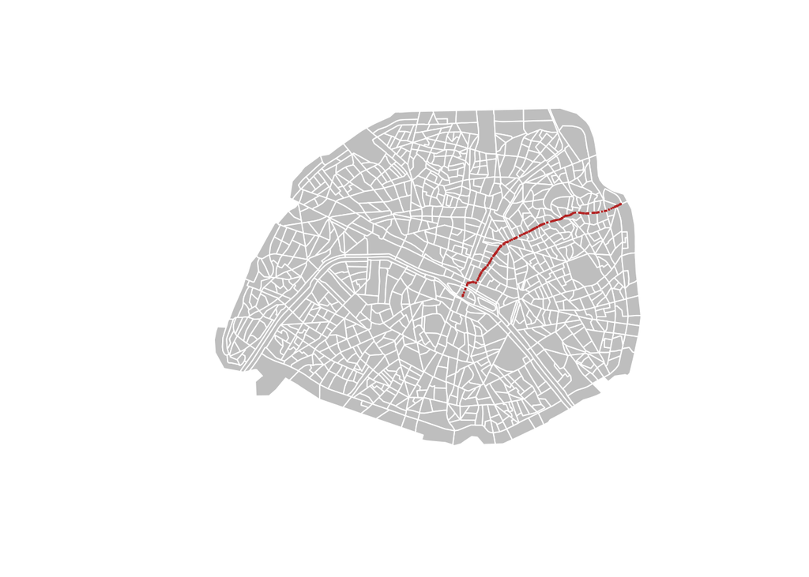

```r
plot(parisNei$geometry, col = "grey", border = "white")
plot(myRouteProj$geometry, pch = 4, cex = 0.1, col = "firebrick", add = TRUE)
```

## Objects to produce

- **Object:** interactive map of the city walk with the Paris neighborhoods
- **Operations to perform:**
1. Create a line from the collection o points [`st_linestring()`, `st_sf()`]
2. Re-project the Paris neighborhoods [`st_transform()`]
3. Map the neighborhoods and the line on OSM tiles [`leaflet()`, `addTiles()`, `addPolygons()`, `addPolylines()`]
- **Object:** static map of the city walk with the income grid (median income as choropleth)
- **Operations to perform:**
1. Create a line from the collection o points [`st_linestring()`, `st_sf()`]
2. Cut or mask the population grid with a relevant bounding polygon or bounding box [`st_bbox()`, `st_intersects()` or `st_contains()` or `st_crop()`]
3. Create a choropleth layer with the median income for each cell of the grid with the `cartography` package [`choroLayer()`]
4. Add the spatial line representing the city walk [`plot()`]
- **Object:** Elevation profile for my city walk
- **Operations to perform:**
1. extract elevation values from the raster for each GPS point [`raster::extract()`, !warning! `tidyr::extract()`]
2. compute pairwise distances between successive points [`st_distance()`]
3. plot the result: elevation (Y) vs. distance (X)
- **Object:** Income profile for my city walk
- **Operations to perform:**
1. extract income values from the grid for each GPS point [`st_intersects()`]
2. compute pairwise distances between successive points [`st_distance()`]
3. plot the result: elevation (Y) vs. distance (X) [`plot()` or `ggplot()`]